# Practical Machine Learning Course Project

Titi Oyerinde

5/24/2022

## Executive Summary

This is an R Markdown document on JHU Coursera Practical Machine Learning Course Project. The dataset used for this project is based on data collected from accelerometers on the belt, forearm, arm and dumbbell of 6 participants who performed barbell weight lifts exercise correctly and incorrectly in 5 different ways(1). The objective of this project is to predict the manner in which the participants did the exercise. A training and test dataset was provided to build a predictive model. To avoid use of the test dataset during the model training process, the training dataset was divided into training and validation datasets. 4 predictive models were built using the training dataset and predictive accuracy determined with the validation dataset. The model that resulted in the highest accuracy and kappa was then used to predict the 20 activities performed in the test dataset.

## Data Wrangling

The raw training and test dataset was loaded using the readr package. The str function revealed that the training dataset had 19622 obs and 160 variables and the testing dataset had 20 obs and 160 variables. Data wrangling (see code below) was done to get rid of columns with NAs and data irrelevant to the building of the models.

```r
#read both training and testing data
library(readr)
training_data<-read_csv("https://d396qusza40orc.cloudfront.net/predmachlearn/pml-training.csv")
testing_data<-read_csv("https://d396qusza40orc.cloudfront.net/predmachlearn/pml-testing.csv")
str(training_data)
```

[output not shown]

[output cut: 210 more lines]

[output not shown]

```r
str(testing_data)
```

[output not shown]

[output cut: 210 more lines]

[output not shown]

```r
#Cleaning training and test datasets
training_data$classe<-as.factor(training_data$classe)
training_data_ss<-training_data[,colSums(is.na(training_data))==0]
testing_data_ss<-testing_data[,colSums(is.na(testing_data))==0]
training_data_ss_final<-training_data_ss[,6:60]
testing_data_ss_final<-testing_data_ss[,6:59]
```

## Model Building and Selection

The training dataset was partitioned into a training and validation dataset and 4 models (Lasso, Decision Tree,Random Forest and Boosting) were built and trained using 20 fold cross validation on the training datasets and then tested against the validation set to determine the most predictive model. All the predictors in the cleaned datasets were used because the LASSO model did not identify common irrelevant predictors across all classes. Below are the steps taken to pick the best model:

```r
#Creating training and validation datasets from original training data
library(caret)
set.seed(2022)
inTrain_RN<-createDataPartition(training_data_ss_final$classe,p=0.75,list=FALSE)
training_data_ss_finalds<-training_data_ss_final[inTrain_RN,]
validation_data<-training_data_ss_final[-inTrain_RN,]
```

```r
# Set cross validation specs for the training dataset
ctrlspecs_tr<-trainControl(method="cv",number=20,savePredictions="all",classProbs = TRUE)
```

### LASSO Regression Model

```r
library(glmnet)
#Create vector of potential lambda values
lambda_vector<-10^seq(5,-5,length=500)
set.seed(2022)
#LASSO regression model fitting
modfit_lasso<-train(classe~.,data=training_data_ss_finalds,preProcess=c("center","scale"),method="glmnet",tuneGrid=expand.grid(alpha=1,lambda=lambda_vector),trControl=ctrlspecs_tr)
## Predict using validation set
predict_lasso<-predict(modfit_lasso,newdata=validation_data)
## Determine LASSO model predictive accuracy
model_lassoperf<-confusionMatrix(predict_lasso,validation_data$classe)
model_lassoperf
```

```
## Confusion Matrix and Statistics
##
##           Reference
## Prediction    A    B    C    D    E
##          A 1198  112   96   64   35
##          B   53  638   77   44   99
##          C   70   91  588   94   61
##          D   57   33   55  566   62
##          E   17   75   39   36  644
##
## Overall Statistics
##
##                Accuracy : 0.741
##                  95% CI : (0.7285, 0.7532)
##     No Information Rate : 0.2845
##     P-Value [Acc > NIR] : < 2.2e-16
##
##                   Kappa : 0.6715
##
##  Mcnemar's Test P-Value : 3.955e-09
##
## Statistics by Class:
##
##                      Class: A Class: B Class: C Class: D Class: E
## Sensitivity            0.8588   0.6723   0.6877   0.7040   0.7148
## Specificity            0.9125   0.9310   0.9220   0.9495   0.9583
## Pos Pred Value         0.7960   0.7003   0.6504   0.7322   0.7941
## Neg Pred Value         0.9420   0.9221   0.9333   0.9424   0.9372
## Prevalence             0.2845   0.1935   0.1743   0.1639   0.1837
## Detection Rate         0.2443   0.1301   0.1199   0.1154   0.1313
## Detection Prevalence   0.3069   0.1858   0.1843   0.1576   0.1654
## Balanced Accuracy      0.8856   0.8016   0.8048   0.8267   0.8365
```

### Prediction Tree Model

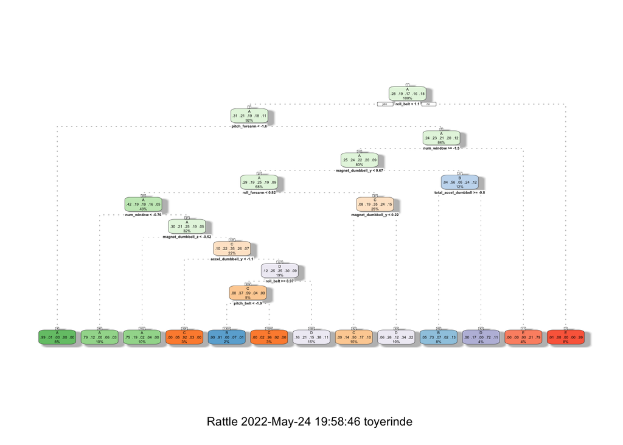

```r
set.seed(2022)
modfit_tree<-train(classe~.,data=training_data_ss_finalds,preProcess=c("center","scale"),method="rpart",tuneLength=8,trControl=ctrlspecs_tr)
library(rattle)
fancyRpartPlot(modfit_tree$finalModel)
```

```r
## Predict using validation set
predict_tree<-predict(modfit_tree,newdata=validation_data)
## Determine Decision Tree predictive accuracy
model_treeperf<-confusionMatrix(predict_tree,validation_data$classe)
model_treeperf
```

```
## Confusion Matrix and Statistics
##
##           Reference
## Prediction    A    B    C    D    E
##          A 1131  143    6   57   16
##          B   17  387   25   14   51
##          C   91  117  657  117   91
##          D  151  302  167  582  181
##          E    5    0    0   34  562
##
## Overall Statistics
##
##                Accuracy : 0.6768
##                  95% CI : (0.6635, 0.6899)
##     No Information Rate : 0.2845
##     P-Value [Acc > NIR] : < 2.2e-16
##
##                   Kappa : 0.5935
##
##  Mcnemar's Test P-Value : < 2.2e-16
##
## Statistics by Class:
##
##                      Class: A Class: B Class: C Class: D Class: E
## Sensitivity            0.8108  0.40780   0.7684   0.7239   0.6238
## Specificity            0.9367  0.97295   0.8973   0.8046   0.9903
## Pos Pred Value         0.8359  0.78340   0.6123   0.4208   0.9351
## Neg Pred Value         0.9257  0.87256   0.9483   0.9369   0.9212
## Prevalence             0.2845  0.19352   0.1743   0.1639   0.1837
## Detection Rate         0.2306  0.07892   0.1340   0.1187   0.1146
## Detection Prevalence   0.2759  0.10073   0.2188   0.2820   0.1226
## Balanced Accuracy      0.8737  0.69037   0.8328   0.7643   0.8070
```

### Random Forest Model

```r
set.seed(2022)
modfit_rf<-train(classe~.,data=training_data_ss_finalds,preProcess=c("center","scale"),method="rf",tuneLength=8,trControl=ctrlspecs_tr)
## Predict using validation set
predict_rf<-predict(modfit_rf,newdata=validation_data)
## Determine Random Forest model predictive accuracy
model_rfperf<-confusionMatrix(predict_rf,validation_data$classe)
model_rfperf
```

```
## Confusion Matrix and Statistics
##
##           Reference
## Prediction    A    B    C    D    E
##          A 1394    3    0    0    0
##          B    1  945    1    0    0
##          C    0    1  854    1    0
##          D    0    0    0  803    1
##          E    0    0    0    0  900
##
## Overall Statistics
##
##                Accuracy : 0.9984
##                  95% CI : (0.9968, 0.9993)
##     No Information Rate : 0.2845
##     P-Value [Acc > NIR] : < 2.2e-16
##
##                   Kappa : 0.9979
##
##  Mcnemar's Test P-Value : NA
##
## Statistics by Class:
##
##                      Class: A Class: B Class: C Class: D Class: E
## Sensitivity            0.9993   0.9958   0.9988   0.9988   0.9989
## Specificity            0.9991   0.9995   0.9995   0.9998   1.0000
## Pos Pred Value         0.9979   0.9979   0.9977   0.9988   1.0000
## Neg Pred Value         0.9997   0.9990   0.9998   0.9998   0.9998
## Prevalence             0.2845   0.1935   0.1743   0.1639   0.1837
## Detection Rate         0.2843   0.1927   0.1741   0.1637   0.1835
## Detection Prevalence   0.2849   0.1931   0.1746   0.1639   0.1835
## Balanced Accuracy      0.9992   0.9976   0.9992   0.9993   0.9994
```

### Boosting Model

```r
set.seed(2022)
library(gbm)
modfit_gbm<-train(classe~.,data=training_data_ss_finalds,preProcess=c("center","scale"),method="gbm",tuneLength=8,trControl=ctrlspecs_tr)
## Predict using validation set
predict_gbm<-predict(modfit_gbm,newdata=validation_data)
## Determine GBM model predictive accuracy
model_gbmperf<-confusionMatrix(predict_gbm,validation_data$classe)
model_gbmperf
```

```
## Confusion Matrix and Statistics
##
##           Reference
## Prediction    A    B    C    D    E
##          A 1395    0    0    0    0
##          B    0  949    1    0    0
##          C    0    0  854    0    0
##          D    0    0    0  804    0
##          E    0    0    0    0  901
##
## Overall Statistics
##
##                Accuracy : 0.9998
##                  95% CI : (0.9989, 1)
##     No Information Rate : 0.2845
##     P-Value [Acc > NIR] : < 2.2e-16
##
##                   Kappa : 0.9997
##
##  Mcnemar's Test P-Value : NA
##
## Statistics by Class:
##
##                      Class: A Class: B Class: C Class: D Class: E
## Sensitivity            1.0000   1.0000   0.9988   1.0000   1.0000
## Specificity            1.0000   0.9997   1.0000   1.0000   1.0000
## Pos Pred Value         1.0000   0.9989   1.0000   1.0000   1.0000
## Neg Pred Value         1.0000   1.0000   0.9998   1.0000   1.0000
## Prevalence             0.2845   0.1935   0.1743   0.1639   0.1837
## Detection Rate         0.2845   0.1935   0.1741   0.1639   0.1837
## Detection Prevalence   0.2845   0.1937   0.1741   0.1639   0.1837
## Balanced Accuracy      1.0000   0.9999   0.9994   1.0000   1.0000
```

# Compare models predictive performance based on validation dataset

```r
comp_perf<-matrix(c(model_lassoperf$overall[[1]],model_lassoperf$overall[[2]],
                    model_treeperf$overall[[1]],model_treeperf$overall[[2]],
                    model_rfperf$overall[[1]],model_rfperf$overall[[2]],
                    model_gbmperf$overall[[1]],model_gbmperf$overall[[2]]),ncol=2,byrow= TRUE)

#Name the columns and rows of comparison matrix
colnames(comp_perf)<-c("Accuracy","Kappa")
rownames(comp_perf)<-c("LASSO","Prediction_Tree","Random Forest","GBM")
comp_perf<-as.table(comp_perf)
comp_perf
```

```
##                  Accuracy     Kappa
## LASSO           0.7410277 0.6715161
## Prediction_Tree 0.6767945 0.5935159
## Random Forest   0.9983687 0.9979365
## GBM             0.9997961 0.9997421
```

One can see from the comparison table above that the GBM(Boosting) resulted in the highest accuracy and highest kappa, thus the GBM model is selected to be the best prediction model for this dataset and used to predict the activities of the participants in the test dataset.

### Out of sample error

Since this is a multi-classification problem,kappa will be used as our measure of error. Based on the table above the GBM kappa is **0.9997421** and thus we will expect our out of sample kappa to be slightly less than this value and at most this value.

## Test Dataset Prediction

Below is the prediction using the GBM model and the test dataset

```r
set.seed(2022)
# Predict the classe of 20 test data cases
predict_gbm_test<-predict(modfit_gbm,newdata=testing_data_ss_final)
predict_gbm_test
```

```
##  [1] B A B A A E D B A A B C B A E E A B B B
## Levels: A B C D E
```

1. Velloso, E.; Bulling, A.; Gellersen, H.; Ugulino, W.; Fuks, H. Qualitative Activity Recognition of Weight Lifting Exercises. Proceedings of 4th International Conference in Cooperation with SIGCHI (Augmented Human ’13) . Stuttgart, Germany: ACM SIGCHI, 2013.